# AP-4209 ESIEE-Paris: 2024 - 2025

Fouille de données avec R pour la data science et l’intelligence artificielle

III.TD 3 : Partie II - ANALYSE FACTORIELLE DISCRIMINANTE

Badr TAJINI – ESIEE Paris  
Source : Bertrand Roudier – ESIEE Paris

### 1. Introduction

Ce TD a pour objectif de réaliser une analyse factorielle discriminante nous permettant :

- à l’aide d’une diminution de dimentionnalité, de visualiser les données dans le plan des axes facoriels (cf.cours)
- d’effectuer, pour chaque axe, une inférence statistique qui permet de tester la discrimination des différentes classes projetées.

Au total, l’AFD est analogue à une MANOVA, nous permettant de réaliser, de manière concomitante, une visualisation des données.

Pour y parvenir, nous utiliserons le jeu de données *VIN_QUALITE.txt*

### 2. Prés-Requis

- Nous chargeons le fichier *VIN_QUALITE.txt*
- Nous utilisons la fonction que nous avons développée lors du précédant TP pour calculer les sommes des carrés totaux, inter et intra.

```r
# à compléter

library(ggplot2)
library(dplyr)
```

```r
# à compléter

vin <- read.table("VIN_QUALITE.txt", header = TRUE, stringsAsFactors = FALSE)
head(vin)
```

```
##     TP Soleil Chaleur Pluie Qualite
## 1 3064   1201      10   361   moyen
## 2 3000   1053      11   338 mauvais
## 3 3155   1133      19   393   moyen
## 4 3085    970       4   467 mauvais
## 5 3245   1258      36   294     bon
## 6 3267   1386      35   225     bon
```

```r
# à compléter

Y <- factor(vin$Qualite)

X <- vin %>% select(-TP, -Qualite)

df_manova <- data.frame(X, Qualite = Y)

# ta fonction MANOVA doit être disponible dans ce Rmd
res_m <- MANOVA(df_manova, "Qualite")

SS_tot   <- res_m$SS_tot
SS_intra <- res_m$SS_Intra
SS_inter <- res_m$SS_Inter

N <- res_m$N
P <- res_m$P
K <- length(levels(Y))
```

Les résultats sont les suivants:

- La somme des carrés totaux : *SS <sub>Tot</sub>*

```r
# à compléter

SS_tot
```

```
##             Soleil    Chaleur      Pluie
## Soleil   529101.44  27056.941 -180803.85
## Chaleur   27056.94   3310.941  -12119.35
## Pluie   -180803.85 -12119.353  275690.38
```

- La somme des carrés intra : *SS <sub>Intra</sub>*

```r
# à compléter

SS_intra
```

```
##            Soleil   Chaleur      Pluie
## Soleil  202192.37  5245.220  -4898.030
## Chaleur   5245.22  1664.371  -1079.515
## Pluie    -4898.03 -1079.515 178499.212
```

- La somme des carrés inter : *SS <sub>Inter</sub>*

```r
# à compléter

SS_inter
```

```
##             Soleil   Chaleur      Pluie
## Soleil   326909.07  21811.72 -175905.82
## Chaleur   21811.72   1646.57  -11039.84
## Pluie   -175905.82 -11039.84   97191.17
```

### 3. Analyse Factorielle Discriminante

#### 3.1 Rappels

Comme nous l’avons vu en cours, l’analyse factorielle discriminante consiste à trouver une succession d’axes factoriels, tous orthogonaux entre eux et qui maximisent les projections des distances entre les groupes (cf. schéma suivant pour rappel)

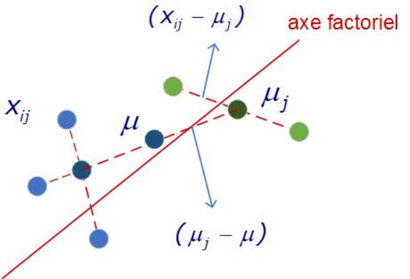

Maximiser les distances entre les groupes revient à maximiser les projections suivantes :

- ${P_1} = {\max _u}\left( {\frac{{{u^t}Bu}}{{{u^t}Wu}}} \right)$ (école Anglo saxonne)

Fort heureusement, les deux méthodes conduisent aux mêmes résultats. Cependant, les approches sont légèrement différentes.

- La méthode anglo-saxonne à un raisonnement analogue à la construction du test d’analyse de variance ou l’on teste le rapport Signal / Bruit (cf. cours page 11). Dans ce cadre, la projection des distances inter groupes est pondérée par les distances intra-groupes
- La méthode française privilégie quant à elle la corrélation canonique c.a.d la part de variation liés au traitement (cf. cours page 11). Dans ce cadre, la projection des distances inter groupes est pondérée par la variation totale

Vous réaliserez une fonction permettant de réaliser une AFD selon la projection *P<sub>1</sub>* (méthode anglo saxonne). Pour y parvenir, nous allons décrire les différentes étapes avec les résultats intermédiaires.

#### 3.2 Diagonalisation

- Nous calculons la matrice du ratio :

  $\frac{B}{W} = \frac{{S{S_{{\rm{inter}}}}}}{{S{S_{{\rm{intra}}}}}} = B \times {W^{ - 1}} = S{S_{{\rm{inter}}}} \times SS_{{\rm{intra}}}^{ - 1}$

Attention la fraction ici correspond à une *division matricielle* et non à une division élément par élément !

Le résultat est le suivant :

```r
# à compléter

BW <- SS_inter %*% solve(SS_intra)
BW
```

```
##              Soleil    Chaleur      Pluie
## Soleil   1.38329950  8.1631132 -0.8981450
## Chaleur  0.08908556  0.6726631 -0.0553355
## Pluie   -0.75602944 -3.9261305  0.5000011
```

Nous calculons maintenant les vecteurs directeurs *u* des axes factoriels et leur coefficient. De manière analogue à l’ACP, la maximisation de
$${P_1} = {\max _u}\left(
{\frac{{{u^t}Bu}}{{{u^t}Wu}}} \right)$$
revient à diagonaliser la matrice $S{S_{{\rm{inter}}}} \times SS_{{\rm{intra}}}^{ - 1}$. Les vecteurs propres correspondent alors aux vecteurs directeurs des axes factoriels. Ces derniers devront être cependant normalisés.
Comme en ACP, les valeurs propres correspondent à la part de dispersion expliquée par chaque axe.

- La diagonalisation est réalisée à l’aide de la fonction *eigen()*
- *remarque importante* : Les algorithmes utilisés peuvent conduire à des matrices de vecteurs propres dont les éléments sont des complexes. *On ne retiendra donc que les parties réels en éliminant les parties complexes* (utiliser la fonction *Re*)

##### 3.2.1 Vecteurs directeurs

- Matrice des vecteurs propres *U*

```r
# à compléter

eig <- eigen(BW)
U <- Re(eig$vectors)
U
```

```
##             [,1]       [,2]        [,3]
## [1,] -0.88070892 -0.4037425 -0.59989317
## [2,] -0.05987083  0.1606579  0.01364044
## [3,]  0.46985879  0.9006559 -0.79996382
```

Contrairement à l’ACP où nous diagonalisons une matrice symétrique (matrice des variances covariances ou de corrélation), la matrice du ratio *B/W* n’est pas symétrique ce qui conduit à des résultats non exploitables car non normées. Pour y parvenir, nous normalisons la matrice des vecteurs propres :

- Soit *U* la matrice des vecteurs propres: nous calculons *U <sub>Norm</sub>* tel que :

${U_{Norm}} = \frac{U}{{\sqrt {diag({U^t} \times W \times U)} }}$

- la matrice de normalisation (dénominateur) est la suivante :

```r
# à compléter

denom <- sqrt(diag(t(U) %*% SS_intra %*% U))
denom
```

```
## [1] 448.2304 424.6957 426.8834
```

- La matrice des vecteurs propres normalisées *Un* est:

```r
# à compléter

Un <- sweep(U, 2, denom, "/")
Un
```

```
##               [,1]          [,2]          [,3]
## [1,] -0.0019648577 -0.0009506631 -1.405286e-03
## [2,] -0.0001335716  0.0003782895  3.195354e-05
## [3,]  0.0010482529  0.0021207088 -1.873963e-03
```

##### 3.2.2 Valeurs propres

- Comme pour les vecteurs propres, nous éliminons la partie imaginaire. les valeurs sont les suivantes:

```r
# à compléter

lambda <- Re(eig$values)
lambda[abs(lambda) < 1e-7] <- 0
lambda[lambda < 0 & abs(lambda) < 1e-7] <- 0
lambda
```

```
## [1] 2.4173911 0.1385726 0.0000000
```

${I_i} = \frac{{{\lambda _i}}}{{\sum\limits_i {{\lambda _i}} }}$

Les parts de dispersion sont les suivantes :

```r
# à compléter

inertie_axes <- lambda / sum(lambda)
inertie_axes
```

```
## [1] 0.94578461 0.05421539 0.00000000
```

#### 3.3 Coordonnées des individus

Le calcul des coordonnées des individus sur les axes factoriels (appelées *scores* en anglais) s’effectue en réalisant la projection des observations X **(centrées)** sur les axes factoriels. Les scores sont simplement calculés comme suit :

$Score = Z \times {U_{Norm}}$

Sachant que pour chaque variable *i* de *X* avec ${Z_j} = {X_j} - {{\bar X}_j}$, il suffit donc de multiplier les données centrées *Z* par *Unorm*

Seuls les deux premiers axes factoriels sont à prendre en compte puisqu’ils représentent à eux seul l’intégralité de la dispersion et donc de “l’information contenu dans le tableau initial *Z*”.

Nous créons un data.frame *Scores_df* qui inclue les coordonnées des individus sur les deux premiers axes factoriels ainsi que les différentes classes auxquelles ils appartiennent (variable ‘Class’). On prendra soin de bien vérifier que l’entête de la variable (nom de la variable) soit égale à *‘Class’*

[output not shown]

[output not shown]

[output cut: 20 more lines]

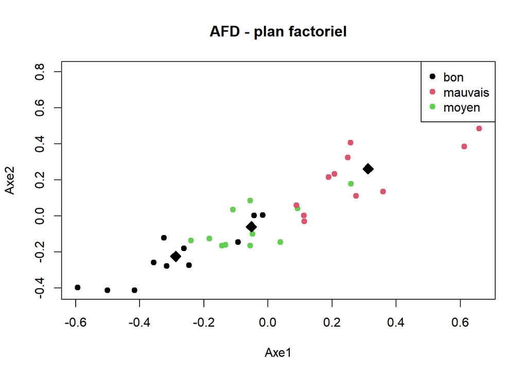

```r
# à compléter

AFD_graph1(Scores_df)
```

[figure not shown]

```r
# à compléter

ggplot(Scores_df, aes(x = Axe1, y = Axe2, color = Class)) +
  geom_point(size = 2) +
  stat_summary(fun = mean, geom = "point", shape = 18, size = 4) +
  theme_minimal()
```

#### 3.4 Inférence statistique

Nous effectuons un test de Wilks. En analyse factorielle discriminante, il s’agit de tester successivement le caractère discriminant des axes vis à vis des différentes classes.

Pour y parvenir, nous calculons les corrélations canoniques de chaque axe. Soit $\rho$, la valeur propre associée à chaque axe, la corrélation canonique est :

$${\eta ^2} = \frac{\rho }{{1 + \rho
}}$$

les corrélations canoniques des deux premiers axes sont:

```r
# à compléter

eta2 <- lambda / (1 + lambda)
eta2[1:2]
```

```
## [1] 0.7073791 0.1217073
```

Dans ce TD, nous allons simplifier les hypothèses. Sous Ho, nous posons que les corrélations canoniques des axes factoriels retenus sont égales à zero *versus* H1: au moins une des corrélations différent.

Le test est le suivant:

$$\left\{ \begin{array}{l}
{H_0}:\eta _{{\rm{axe 1}}}^2 = \eta _{{\rm{axe 2}}}^2 = 0\\
{H_1}:{\rm{ }}\eta _{{\rm{axe 1}}}^2{\rm{ et / ou }}\eta _{{\rm{axe
2}}}^2 \ne 0
\end{array} \right.$$

Nous calculons la quantité de Wilks $Wilks = {\Lambda _i} = \prod\limits_{i = 1}^2 {(1 - \lambda _i^2)}$

- rmq : Pour la calculer, on utilisera la fonction *cumsum()*

La quantité suivante suit une distribution de Chi-deux

$$- \left( {n - 1 - \frac{{p + k}}{2}}
\right)\log (\Lambda ) \to \chi _{p(k - 1)ddl}^2$$

avec:

- n: le nombre total d’observations
- p: le nombre de variables
- k: le nombre de classes

Pour les deux premiers axes retenus *(axe_selected = 2)*, L’ensemble des résultats de l’ADF sont résumés dans le tableau :

```r
# à compléter

axe_selected <- 2

wilks_tbl <- data.frame(
  Axe = 1:axe_selected,
  Lambda = NA_real_,
  Chi2 = NA_real_,
  ddl = NA_integer_,
  p_value = NA_real_
)

for (i in 1:axe_selected) {
  Lambda_i <- prod(1 - eta2[i:axe_selected])
  Chi2_i   <- - (N - 1 - (P + K)/2) * log(Lambda_i)
  ddl_i    <- (P - i + 1) * (K - 1)
  p_i      <- 1 - pchisq(Chi2_i, df = ddl_i)

  wilks_tbl$Lambda[i]  <- Lambda_i
  wilks_tbl$Chi2[i]    <- Chi2_i
  wilks_tbl$ddl[i]     <- ddl_i
  wilks_tbl$p_value[i] <- p_i
}

wilks_tbl
```

```
##   Axe    Lambda     Chi2 ddl      p_value
## 1   1 0.2570068 40.75958   6 3.229201e-07
## 2   2 0.8782927  3.89326   4 4.206442e-01
```

### 4. Encapsulation du code

Pour rappel, l’AFD est une méthode de classification supervisée. Le présent TD nous a permis de développer des scripts permettant:

- De calculer les axes factoriels relatives aux projections du compromis B/W
- De positionner les individus dans le plan factoriel ce qui permet de visualiser les positions des individus et des groupes les uns par rapport aux autres
- De tester la qualité de la projection et de la discrimination des groupes sur les axes factoriels

Le prochain TD aura pour objectif d’utiliser les coordonnées des observations dans le plan factoriel pour réaliser un classifieur supervisée dont nous testerons la qualité à l’aide d’une matrice des confusions.

Remarque : En cas de *non* discrimination des classes par les axes factoriels (acceptation de Ho et rejet de H1), il est évident qu’il n’est pas possible d’utiliser les projections des individus sur les axes factoriels pour réaliser un classifieur. Dans ce cas, la classification supervisée n’est pas réalisable par cette méthode

Nous créons une fonction générique que nous nommons *AFD*. Les arguments de la fonction sont les suivants :

- AFD <- function(X,Y,SS_tot, SS_intra, SS_inter, nb_axes = 2)
  - X et Y sont respectivement les variables prédictives et Y la variable à prédire
  - SS_tot, SS_intra, SS_inter sont les sommes des carrés calculées à partir de la fonction *MANOVA* que vous avez développée
  - nb_axes est le nombre d’axes sélectionné pour réaliser les projections. Par défaut, il est égal à 2 (projection dans un plan)

Cette fonction retourne une liste dont les éléments sont les suivants (sous forme de data frame):

- les vecteurs propres normalisés (appelés aussi *loading factors* en anglais)
- les valeur propres
- les scores
- le tableau des résultats du test de Wilks

Le data frame des Scores calculés à partir da la fonction *AFD* corresppondent à l’argument de la fonction *AFD_graph1*

Le script final (avec les résultats) doit être le suivant :

```r
# à compléter

AFD <- function(X, Y, SS_tot, SS_intra, SS_inter, nb_axes = 2) {
  Y <- factor(Y)
  X_mat <- as.matrix(X)

  N <- nrow(X_mat)
  P <- ncol(X_mat)
  K <- length(levels(Y))

  BW <- SS_inter %*% solve(SS_intra)
  eig <- eigen(BW)

  U <- Re(eig$vectors)
  lambda <- Re(eig$values)

  lambda[abs(lambda) < 1e-7] <- 0
  lambda[lambda < 0 & abs(lambda) < 1e-7] <- 0

  denom <- sqrt(diag(t(U) %*% SS_intra %*% U))
  Un <- sweep(U, 2, denom, "/")

  Z <- scale(X_mat, center = TRUE, scale = FALSE)
  Scores <- Z %*% Un

  Scores_df <- data.frame(
    Axe1 = Scores[, 1],
    Axe2 = Scores[, 2],
    Class = Y
  )

  eta2 <- lambda / (1 + lambda)

  axe_selected <- nb_axes
  wilks_tbl <- data.frame(
    Axe = 1:axe_selected,
    Lambda = NA_real_,
    Chi2 = NA_real_,
    ddl = NA_integer_,
    p_value = NA_real_
  )

  for (i in 1:axe_selected) {
    Lambda_i <- prod(1 - eta2[i:axe_selected])
    Chi2_i   <- - (N - 1 - (P + K)/2) * log(Lambda_i)
    ddl_i    <- (P - i + 1) * (K - 1)
    p_i      <- 1 - pchisq(Chi2_i, df = ddl_i)

    wilks_tbl$Lambda[i]  <- Lambda_i
    wilks_tbl$Chi2[i]    <- Chi2_i
    wilks_tbl$ddl[i]     <- ddl_i
    wilks_tbl$p_value[i] <- p_i
  }

  list(
    Un = Un,
    lambda = lambda,
    Scores_df = Scores_df,
    wilks_tbl = wilks_tbl
  )
}
```

```r
# à compléter

afd_res <- AFD(X, Y, SS_tot, SS_intra, SS_inter, nb_axes = 2)

afd_res$Un
```

```
##               [,1]          [,2]          [,3]
## [1,] -0.0019648577 -0.0009506631 -1.405286e-03
## [2,] -0.0001335716  0.0003782895  3.195354e-05
## [3,]  0.0010482529  0.0021207088 -1.873963e-03
```

```r
afd_res$lambda
```

```
## [1] 2.4173911 0.1385726 0.0000000
```

```r
head(afd_res$Scores_df)
```

```
##          Axe1        Axe2   Class
## 1  0.09278350  0.04188533   moyen
## 2  0.35933905  0.13418546 mauvais
## 3  0.25873577  0.17779771   moyen
## 4  0.65858186  0.48401391 mauvais
## 5 -0.09291919 -0.14455444     bon
## 6 -0.41661685 -0.41294652     bon
```

```r
afd_res$wilks_tbl
```

```
##   Axe    Lambda     Chi2 ddl      p_value
## 1   1 0.2570068 40.75958   6 3.229201e-07
## 2   2 0.8782927  3.89326   4 4.206442e-01
```

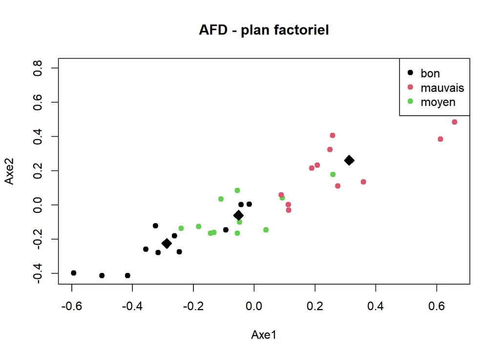

```r
AFD_graph1(afd_res$Scores_df)
```

### 5. Application

Pour valider votre fonction, vous utiliserez le fichier iris fourni par défaut en R.

Les résultats sont les suivants :

```r
# à compléter

data(iris)

X_iris <- iris[, 1:4]
Y_iris <- iris$Species

res_m_iris <- MANOVA(data.frame(X_iris, Species = Y_iris), "Species")

afd_iris <- AFD(
  X_iris, Y_iris,
  res_m_iris$SS_tot,
  res_m_iris$SS_Intra,
  res_m_iris$SS_Inter,
  nb_axes = 2
)

afd_iris
```

```
## $Un
##             [,1]       [,2]         [,3]         [,4]
## [1,]  0.05046534 0.06663183  0.107295743  0.107295743
## [2,] -0.01780390 0.12217656  0.027831184  0.027831184
## [3,]  0.13381272 0.03005367  0.062069412  0.062069412
## [4,]  0.05706685 0.06283138 -0.001755236 -0.001755236
##
## $lambda
## [1] 32.191929  0.285391  0.000000  0.000000
##
## $Scores_df
##             Axe1          Axe2      Class
## 1   -0.417952952 -0.1291022148     setosa
## 2   -0.419144069 -0.2035168626     setosa
## 3   -0.446179189 -0.1954132825     setosa
```

[output cut: 152 more lines]

- Matrice des vecteurs propres normalisées

```r
# à compléter

afd_iris$Un
```

```
##             [,1]       [,2]         [,3]         [,4]
## [1,]  0.05046534 0.06663183  0.107295743  0.107295743
## [2,] -0.01780390 0.12217656  0.027831184  0.027831184
## [3,]  0.13381272 0.03005367  0.062069412  0.062069412
## [4,]  0.05706685 0.06283138 -0.001755236 -0.001755236
```

```r
# à compléter

afd_iris$lambda
```

```
## [1] 32.191929  0.285391  0.000000  0.000000
```

- Scores

```r
# à compléter

head(afd_iris$Scores_df)
```

```
##         Axe1        Axe2  Class
## 1 -0.4179530 -0.12910221 setosa
## 2 -0.4191441 -0.20351686 setosa
## 3 -0.4461792 -0.19541328 setosa
## 4 -0.4226828 -0.20828339 setosa
## 5 -0.4247799 -0.12354774 setosa
## 6 -0.3583777 -0.03865966 setosa
```

- Tests MANOVA axes factoriels

```r
# à compléter

afd_iris$wilks_tbl
```

```
##   Axe     Lambda      Chi2 ddl      p_value
## 1   1 0.02343863 546.11530   8 0.000000e+00
## 2   2 0.77797337  36.52966   6 2.174469e-06
```

- Si vous trouvez les mêmes résultats c’est que vous avez bien travaillé !